# Weather lab meeting

jesse puka-beals

2022-11-30

# Weather data

I went on the google drive and typed in “weather data”

This was one of the first hits

https://docs.google.com/spreadsheets/d/1By_xv0TOeNumPEBQChkT3BWN6q_bBKHA/edit#gid=1780485077

```r
# library(googlesheets4)
#
# url <- "https://docs.google.com/spreadsheets/d/1By_xv0TOeNumPEBQChkT3BWN6q_bBKHA/edit#gid=1780485077"
#
# read_sheet(url,
#            # gs4_deauth()
#            )
# got an errror I don't understand, I give up immediately
```

Went to the All Rosemount Weather Data tab, hit file and download csv

Moving that csv into my project directory “r-practice”

```r
read.csv("weather_data_rosemount.csv") -> dat

dat %>%
  # colnames()
  dplyr::rename(
    date = Date,
    min_F = Minimum.Temperature.degrees..F.,
    max_F = Maximum.Temperature.degrees..F.,
    precip_inch = Precipitation..inches.,
    snow_in = Snow..inches.,
    snow_depth = Snow.Depth..inches.
  )  %>%
  # colnames()
  # glimpse()
  mutate(date = as.POSIXct(date,
                           format = "%m/%d/%Y"),
         year = format(date,"%Y"),
         month = format(date,"%m"),
         day = format(date, "%d"),
         .after = date) -> dat1
  # glimpse()

# dat1 %>%
#   mutate(across(
#     .cols = 6,
#     na_if("M")
#   ))

dat1 %>%
  # mutate(max_F = na_if(max_F,"M"),
  #        min_F = na_if(min_F,"M")) %>%
  mutate(max_F = as.numeric(max_F),
         min_F = as.numeric(min_F),
         precip_inch = as.numeric(precip_inch))  -> dat2
```

# summarise data

By year and month, we want mean high temp, mean low temp, mean temp, mean precip

```r
options(digits = 2)

dat2 %>%
  filter(year >= 2019 &
           year != 2022) %>%
  group_by(year,month) %>%
  # glimpse()
  drop_na(
    max_F,
    min_F
    # precip_inch
    ) %>% #similar to na.omit() but drops entire row
  summarise(
    n=n(),
    temp_max_F=mean(na.omit(max_F)),
    temp_min_F=mean(na.omit(min_F)),
    temp_mean_F = mean((temp_max_F+temp_min_F)/2),
    precip_inch = mean(na.omit(precip_inch))
    ) -> sum.tab1
sum.tab1
```

```
## # A tibble: 36 × 7
## # Groups:   year [3]
##    year  month     n temp_max_F temp_min_F temp_mean_F precip_inch
##    <chr> <chr> <int>      <dbl>      <dbl>       <dbl>       <dbl>
##  1 2019  01       31       20.5       3.77       12.1       0.024
##  2 2019  02       28       18.5      -2.07        8.21      0.159
##  3 2019  03       31       34.6      13.7        24.2       0.0841
##  4 2019  04       30       53.8      33.8        43.8       0.183
##  5 2019  05       31       62.4      43.5        53.0       0.262
##  6 2019  06       30       78        57.6        67.8       0.115
##  7 2019  07       30       82.3      62.9        72.6       0.354
##  8 2019  08       28       77.5      57.4        67.4       0.176
##  9 2019  09       30       73.4      54.1        63.8       0.274
## 10 2019  10       31       53.0      35.3        44.2       0.195
## # … with 26 more rows
```

# calculate 30 year average

```r
dat2 %>%
  filter(year >= 2021-30) %>%
  group_by(month) %>%
  # glimpse()
  drop_na(
    max_F,
    min_F
    # precip_inch
    ) %>% #similar to na.omit() but drops entire row
  summarise(
    n=n(),
    temp_max_F=mean(na.omit(max_F)),
    temp_min_F=mean(na.omit(min_F)),
    temp_mean_F = mean((temp_max_F+temp_min_F)/2),
    precip_inch = mean(na.omit(precip_inch))
    ) -> sum.tab2

sum.tab2 %>%
  # glimpse()
  mutate(year = "30-yr",.before=month) -> sum.tab3

sum.tab1 %>%
  bind_rows(sum.tab3) -> sum.tab4
  # glimpse()
  # distinct(year)

# now let's look at the summary table

sum.tab4
```

```
## # A tibble: 48 × 7
## # Groups:   year [4]
##    year  month     n temp_max_F temp_min_F temp_mean_F precip_inch
##    <chr> <chr> <int>      <dbl>      <dbl>       <dbl>       <dbl>
##  1 2019  01       31       20.5       3.77       12.1       0.024
##  2 2019  02       28       18.5      -2.07        8.21      0.159
##  3 2019  03       31       34.6      13.7        24.2       0.0841
##  4 2019  04       30       53.8      33.8        43.8       0.183
##  5 2019  05       31       62.4      43.5        53.0       0.262
##  6 2019  06       30       78        57.6        67.8       0.115
##  7 2019  07       30       82.3      62.9        72.6       0.354
##  8 2019  08       28       77.5      57.4        67.4       0.176
##  9 2019  09       30       73.4      54.1        63.8       0.274
## 10 2019  10       31       53.0      35.3        44.2       0.195
## # … with 38 more rows
```

Put the data in a wider format for table

```r
sum.tab4 %>%
  dplyr::select(-c(n,temp_max_F,temp_min_F)) %>%
  pivot_wider(
    names_from = year,
    values_from = c(temp_mean_F,precip_inch))
```

```
## # A tibble: 12 × 9
##    month temp_mean_F_2…¹ temp_…² temp_…³ temp_…⁴ preci…⁵ preci…⁶ preci…⁷ preci…⁸
##    <chr>           <dbl>   <dbl>   <dbl>   <dbl>   <dbl>   <dbl>   <dbl>   <dbl>
##  1 01              12.1     18.2   19.5     14.1  0.024   0.110   0.0328  0.0463
##  2 02               8.21    16.7    8.62    17.6  0.159   0.0231  0.11    0.0388
##  3 03              24.2     32.7   38.4     31.5  0.0841  0.0567  0.103   0.0697
##  4 04              43.8     52.6   44.9     45.5  0.183   0       0.107   0.122
##  5 05              53.0     56.5   57.5     58.1  0.262   0.112   0.13    0.172
##  6 06              67.8     70.0   73.7     68.2  0.115   0.39    0.0628  0.192
##  7 07              72.6     73.6   72.4     71.9  0.354   0.0908  0.0479  0.172
##  8 08              67.4     70.3   71.1     69.5  0.176   0.199   0.176   0.175
##  9 09              63.8     58.7   62.5     62.1  0.274   0.0611  0.111   0.138
## 10 10              44.2     40.8   53.6     48.7  0.195   0.120   0.123   0.102
## 11 11              28.3     37.0   34.6     33.6  0.0635  0.0452  0.0378  0.0720
## 12 12              20.1     23.2   21.8     20.5  0.0927  0.02    0.0696  0.0497
## # … with abbreviated variable names ¹temp_mean_F_2019, ²temp_mean_F_2020,
## #   ³temp_mean_F_2021, ⁴`temp_mean_F_30-yr`, ⁵precip_inch_2019,
## #   ⁶precip_inch_2020, ⁷precip_inch_2021, ⁸`precip_inch_30-yr`
```

Clearer format

```r
sum.tab4 %>%
  group_by(year) %>%
  summarise(temp=mean(temp_mean_F),
            rain = mean(precip_inch))
```

```
## # A tibble: 4 × 3
##   year   temp   rain
##   <chr> <dbl>  <dbl>
## 1 2019   42.1 0.165
## 2 2020   45.9 0.102
## 3 2021   46.6 0.0926
## 4 30-yr  45.1 0.112
```

# Add in GDD

Convert everything to C

start at first day of the year

calculate GDD units for a given day (Tmax-Tmin)/2-Tbase

Detect 5 days where average day is above 0C

For each year, start a cumulative tally at the starting point

```r
library(measurements)
options(scipen = 999, digits = 2)

dat2 %>%
  filter(year >= 2019 &
           year != 2022) %>%
  # colnames()
  mutate(max_C = conv_unit(max_F,"F","C"),
         min_C = conv_unit(min_F,"F","C"),
         precip_mm = conv_unit(precip_inch,"inch","mm")) %>%
  dplyr::select(-c(max_F,min_F,snow_in,snow_depth,precip_inch)) -> dat3
```

calculate GDD units for a given day (Tmax-Tmin)/2-Tbase

```r
GDD_calc <- function(Tmax,Tmin){
  # (Tmax-Tmin)/2-Tbase
  Tmax = if_else(Tmax>30, 30,Tmax)
  Tmax = if_else(Tmax<0,0,Tmax)
  Tmin = if_else(Tmin<0,0,Tmin)
  Tmin = if_else(Tmin>30,30,Tmin)
  Tbase = 0
  (Tmax-Tmin)/2-Tbase
}

rounder <- function(x){
  round(x,2)
}

dat3 %>%
  mutate(gdd = GDD_calc(max_C,min_C),
         max_C = rounder(max_C),
         min_C = rounder(min_C),
         gdd = rounder(gdd),
         mean_C = (max_C+min_C)/2) %>%
  relocate(precip_mm,.before = max_C) -> dat4
```

# calculating GDD

This is where I cannot figure out an elegant repeatable way to do this

Every year will have a different start point and then you will need to create a cumulative sum for that year, but then stop after the year if over and reset

I would need a function that would start a cumulative sum after a certain condition is met for a given year and end it after the year is over.

**HELP**

How do I calculate GDD cumulatively in R

For a given year, I need to find 5 rows that

start at first day of the year

Detect 5 days where average day is above 0C

For each year, start a cumulative tally at the starting point

```r
dat5 <- dat4

for (i in 1:length(dat5$date)) {
  ifelse(
    dat5$mean_C[i] > 0 & #once
      dat5$mean_C[i+1] > 0 &
      dat5$mean_C[i+2] > 0 &
      dat5$mean_C[i+3] > 0 &
      dat5$mean_C[i+4] > 0,
    dat5$start[i] <-  "start",
    dat5$start[i] <-  NA
  )
}
# we only want one start in a year, not sure how to deal with that

# quick hack
dat5 %>%
  rowid_to_column() %>%
  filter(year=="2021") %>%
  filter(start=="start") %>%
  head(1) %>%
  pull(rowid)
```

```
## [1] 797
```

```r
# 79 for 2019
# 448 for 2020
# 797 for 2021

##UGLY HARD CODING, RUN AWAY
```

The second we are hard coding we run away

Because I don’t know how to do this elegantly, we will separate out by year, then join back together

```r
# 2019

dat5 %>%
  filter(year=="2019") %>%
  mutate(gdd2 = gdd) -> dat5_2019

dat5_2019 %>%
  rowid_to_column() %>%
  filter(start=="start") %>%
  head(1) %>%
  pull(rowid)
```

```
## [1] 79
```

```r
# this is where we start counting GDD

dat5_2019$gdd2[1:79-1] <- 0

# we will call cumsum on the entire gdd2 column, but we have forced all the gdd values prior to the start to be 0

dat5_2019 %>%
  drop_na(gdd2) %>%
  mutate(gdd_cumulative = cumsum(gdd2)) -> dat5_2019a

#### NOW WE DO IT AGAIN ####

# 2020

dat5 %>%
  filter(year=="2020") %>%
  mutate(gdd2 = gdd) -> dat5_2020

dat5_2020 %>%
  rowid_to_column() %>%
  filter(start=="start") %>%
  head(1) %>%
  pull(rowid)
```

```
## [1] 83
```

```r
# this is where we start counting GDD

dat5_2020$gdd2[1:83-1] <- 0

# we will call cumsum on the entire gdd2 column, but we have forced all the gdd values prior to the start to be 0

dat5_2020 %>%
  drop_na(gdd2) %>%
  mutate(gdd_cumulative = cumsum(gdd2)) -> dat5_2020a

#### NOW WE DO IT AGAIN ####

# 2021

dat5 %>%
  filter(year=="2021") %>%
  mutate(gdd2 = gdd) -> dat5_2021

dat5_2021 %>%
  rowid_to_column() %>%
  filter(start=="start") %>%
  head(1) %>%
  pull(rowid)
```

```
## [1] 66
```

```r
# this is where we start counting GDD

dat5_2021$gdd2[1:66-1] <- 0

# we will call cumsum on the entire gdd2 column, but we have forced all the gdd values prior to the start to be 0

dat5_2021 %>%
  drop_na(gdd2) %>%
  mutate(gdd_cumulative = cumsum(gdd2)) -> dat5_2021a


## NOW WE JOIN ## UGH

bind_rows(
  dat5_2019a,
  dat5_2020a,
  dat5_2021a
) -> dat6

# rm(dat5_2019,dat5_2019a,dat5_2020,dat5_2020a,dat5_2021,dat5_2021a)
```

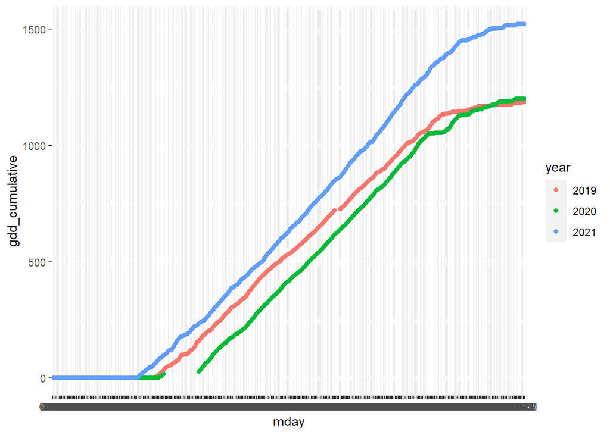

```r
dat6 %>%
  # colnames()
  mutate(mday = format(date,"%m-%d")) %>%
  ggplot(aes(mday,gdd_cumulative,
             color = year)) +
  geom_point()
```